# Tarea 2

# 1 Guerra de Métodos

**Determina las raíces de las siguientes funciones con el método que prefieras. Explica cual es el método ideal para cada función y reporta el error numérico adecuadamente.**

**Gráfica las funciones para que determines el intervalo a evaluar, si hay varios intervalos posibles, escoge el que prefieras explicando el porque escoges este intervalo**

Primero vamos a definir funciones para todos los métodos que vamos a usar. Y así sólo tendremos que llamar estas funciones más adelante

```python
# Importamos todo lo que necesitamos
import numpy as np
import matplotlib.pyplot as plt
import pandas as pd
```

**Graficar**

```python
# Definimos una función para graficar funciones

# La función toma la expresión f de la función que queremos graficar
# Y los límites a,b del intervalo en el que graficaremos
# A parte de un título que darle a nuestra gráfica
def grafica(f,a,b,title='función'):
    # Creamos 400 valores entre a y b para la variable x
    x = np.linspace(a,b,400)
    # Evaluamos y = f(x)
    y = f(x)

    # Hacemos la gráfica y le ponemos nombre
    plt.plot(x,y)
    plt.xlabel("eje x")
    plt.ylabel("eje y")
    plt.title(title)

    # Graficamos una línea horizontal con y=0 para que sea el eje x
    plt.plot(x,[0]*len(x),'k--')
    plt.show()
```

**Algoritmos de búsqueda de raíces**

Escribimos ahora el código de los 4 métodos de búsqueda de raíces que usaremos

```python
#Incremental Search

# Toma como argumentos a la función f y los límites a,b y el tamaño del paso dx
def incremental(f,a,b,dx=1e-6):
    # Empezamos desde el punto a
    x0=a
    f0=f(x0)

    # Y un punto ligeramente después de a
    x1=x0+dx
    f1=f(x1)
    contador=0

    # Conforme la función evaluada en dos puntos seguidos tenga el mismo signo
    # Significa que no hemos encontrado el punto donde f cruza el 0
    while f0*f1>=0.0:
        # Si nos pasamos de b, imprimimos el mensaje ´nada´ y el contador
        if x1>=b: return (['nada',contador]) #salgo del bucle infinito

        # Nos movemos un paso dx a la derecha
        x0=x1
        f0=f1
        x1=x0+dx
        f1=f(x1)
        # Aumentamos el contador
        contador+=1

        # Puse un límite del contador igual a 1,000,000. Si en ese entonces
        # no se ha encontrado una raíz, paramos el algoritmo
        # Esto porque sino el algoritmo se tardaba demasiado y no quería
        # que quien califique tardara mucho en correr las celdas
        if contador > 1e6:
            return(['Algoritmo Detenido',np.nan])
            break
    # Imprimimos el valor posible de la raíz y el contador
    # La mejor estimación de la raíz está justo en el punto medio de cuando
    # la función cambia de signo (x0+x1)/2
    return [(x0+x1)/2,contador]



#Biseccion

# Toma como entrada a la función, el intervalo y el margen de error
def biseccion(f,a,b,epsilon=1e-6):
    # Si la función evaluada en los extremos tiene el mismo signo
    # No podemos asegurar que haya una raíz entre estos extremos
    # Pues no podemos usar el teorema del valor intermedio, que es la parte central del algoritmo
    if f(a)*f(b) > 0:
        return(['No puedo asegurar raíz dentro de intervalo',0])
    # Por si justo los límites del intervalo son una raíz de pura casualidad:
    if f(a) ==0:
        return([a,0])
    if f(b)==0:
        return([b,0])


    # El error actual dx es la longitud de nuestro intervalo actual
    # y x es el punto medio
    contador=0
    dx=abs(b-a)
    x=(a+b)/2.0


    # Mientras el error actual sea mayor al margen que queremos epsilon
    while dx>epsilon:
        contador=contador+1

        # calculamos el punto medio del intervalo
        x=(a+b)/2.0

        # Vemos con qúe signo concuerda el signo del valor medio
        # y según ello partimos el intervalo en un lado u otro
        if (f(a)*f(x))<0:
            b=x #izquierda
        elif (f(a)*f(x))>0:
            a=x #derecho


        # Si no se cumple ninguna de las condiciones de arriba,
        # Significa que le atinamos justo a  f(x)=0
        # Y entonces ya paramos el algoritmo
        else:
            return([x,contador])


        # Sino, renombramos el intervalo y aumentamos el contador
        dx=abs(b-a) #renombrar intervalo
    #Regresamos nuestra aproximación de la raíz y el contador
    return [x, contador]


# Newton



# Toma como entrada a la función f, su derivada df y el punto x desde el que empezamos
# Además de la precisión epsilon que buscamos
def newton(f,df,x,epsilon=1e-6):

    dx=2*epsilon
    contador = 0

    # Conforme nuestra precisión sea mayor a epsilon y sean menos de 1000 iteraciones
    while dx> epsilon and contador<1000:
        # usamos la fórmula de Newton para le siguiente punto

        if df(x) !=0:
            x1=x-f(x)/df(x)
        else:
            x1=x-f(x)/(df(x)+0.001)

        # Actualizamos nuestra precisión
        dx=abs(x-x1)
        #actualizamos el valor de x y el contador
        x=x1
        contador=contador+1
    # Si salimos del loop por haber hecho las 1000 iteraciones,
    # Regresamos el mensaje ´detenido´ indicando que tuvimos que detener el programa
    if contador == 1000:
        return['Detenido',contador]
    return [x,contador]





# Secante

# Toma como entrada a la función f, los puntos x0,x1 con los que empezaremos
# Y la precisión buscada delta
# la precisión delta es una medida de qué tan cerca están las últimas iteraciones
def secante(f, x0, x1, delta=1e-6):
    # Evaluamos la función en los puntos x0, x1
    f0 = f(x0)
    f1 = f(x1)
    contador=0

    # Mientras hagamos menos de 1000 pasos
    while contador<1000:
        # Encontramos la intersección de la secante con el eje x


        x2 = x1 - f1 * (x1 - x0) / (f1 - f0) #secante


        # y la evaluamos en f
        f2 = f(x2)
        contador+=1

        # si f evaluado en x2 está más cerca del cero que delta
        # y que el último intervalo sea más pequeño que delta
        if abs(x2-x1) < delta and f2<delta:
            # paramos
            break
        # Sino, actualizamos los valores
        f0 = f1
        f1 = f2
        x0 = x1
        x1 = x2
    # Si salimos del loop por haber hecho las 1000 iteraciones,
    # Regresamos el mensaje ´detenido´ indicando que tuvimos que detener el programa
    if contador == 1000:
        return['Detenido',contador]
    return [x1,contador]
```

Ahora crearemos una función llamada ¨guerra¨ que comparará los 4 algoritmos en una misma función f. Con distintas precisiones, desde una precisión de $10^{-2}$ hasta $10^{-maxi}$ (con maxi una entrada de la función).

El algoritmo corre los 4 métodos para cada una de las precisiones y regresa un data frame con las raíces encontradas por cada método en cada precisión y el contador de cada método.

Además, dibuja gráficas que muestran la cantidad de pasos como función de la precisión buscada para cada uno de los códigos

```python
def guerra(f,a,b,df,maxi=7):
    # Cremos un data frame con 9 columnas.
    # Una columna con las precisiones
    # y cada método tiene dos columnas, una de la raíz y una del contador
    columnas =['Precisión','Incremental raíz', 'Incremental contador',
           'Bisección raíz','Bisección contador',
           'Newton raíz', 'Newton contador',
           'Secante raíz','Secante contador']

    dframe = pd.DataFrame(columns=columnas)




    # Vamos iterando sobre las precisiones, desde 10^(-2) hasta 10^(-maxi)
    for i in range(2,maxi+1):
        # dx es la precisión
        dx=10**(-i)

        # Calculamos la respuesta de usar el método incremental en el intervalo
        # y el contador de este método, con la precisión dx
        incr_res, incr_count = incremental(f,a,b,dx)

        # Lo mismo con el método de bisección
        bis_res, bis_count = biseccion(f,a,b,dx)

        # Y con el método de Newton. El método de newton necesita también la derivada df
        # y empieza en un solo punto, que usaremos el punto medio entre a y b
        newt_res, newt_count = newton(f,df,(b+a)/2,dx)

        # lo mismo con el método de secante para el intervalo a,b
        sec_res, sec_count = secante(f,a,b,dx)

        # Creamos un diccionario con estos resultados
        res = {'Precisión': dx, 'Incremental raíz':incr_res,
        'Incremental contador':incr_count,'Bisección raíz':bis_res,
          'Bisección contador':bis_count,'Newton raíz':newt_res,
            'Newton contador':newt_count,
           'Secante raíz':sec_res,'Secante contador':sec_count}
        # Agregamos los resultados al frame
        dframe=dframe.append(res,ignore_index=True)


    #Esta parte hace las gráficas
    # Iteramos sobre las columnas que tienen los contadores de cada método
    for col in ['Incremental contador','Bisección contador','Newton contador','Secante contador']:
        # Creamos una gráfica de la precisión vs el contador del método en el que estamos
        plt.plot(dframe['Precisión'],dframe[col])
        # le damos nombre
        plt.title('{} vs Precisión'.format(col))

        # la escala de precisión la haremos LOGARÍTMICA
        plt.xscale('log')
        # e invertimos el eje x, pues menor valor de dx indica más precisión
        plt.gca().invert_xaxis()
        # mostramos la gráfica
        plt.show()



    # Arreglamos un poco el data frame para ponerle columnas más bonitas de multinivel
    dframe = dframe.set_index('Precisión')
    dframe.columns =  pd.MultiIndex.from_product([['Incremental', 'Bisección',
                                                   'Newton','Secante'],
                                                  ['Raíz', 'Contador']])
    # Regresamos los primeros renglones del data frame
    return(dframe.head(10))
```

# 1. Encuentra las dos raíces de $2x^2 + 5x - 3$

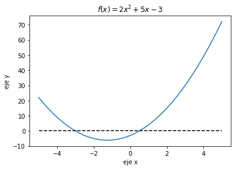

```python
# Definimos la función y su derivada y graficamos
def f(x):
    return(2*x**2+5*x-3)

def df(x):
    return(4*x+5)

grafica(f,-5,5, r'$f(x) = 2x^2 + 5x-3$')
```

Vemos que la función es diferenciable y parece tener dos raíces. Como es una función tan suave, cualquiera de los métodos debería de funcionar adecuadamente. Pero debemos de correrlos dos veces, una en un intervalo que rodee a la primera raíz y una en un intervalo que rodee a la segunda.

Probablmente el mejor método sea el de Newton, pues tiene un error muy pequeño y suele converger muy rápidamente. El método de secante y de bisección también funcionarán bien, pues también mejoran la precisión muy rápidamente.

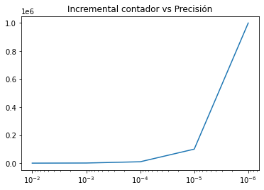

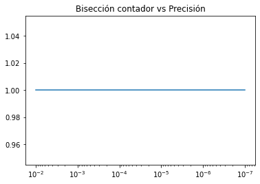

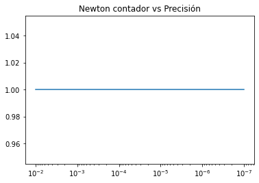

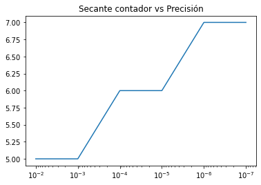

| Precisión | Incremental Raíz | Incremental Contador | Bisección Raíz | Bisección Contador | Newton Raíz | Newton Contador | Secante Raíz | Secante Contador |
| --- | --- | --- | --- | --- | --- | --- | --- | --- |
| 1.000000e-02 | -2.995 | 100.0 | -3.0 | 1.0 | -3.0 | 1.0 | -2.999607 | 5.0 |
| 1.000000e-03 | -2.9995 | 1000.0 | -3.0 | 1.0 | -3.0 | 1.0 | -2.999607 | 5.0 |
| 1.000000e-04 | -3.00005 | 9999.0 | -3.0 | 1.0 | -3.0 | 1.0 | -3.000001 | 6.0 |
| 1.000000e-05 | -3.000005 | 99999.0 | -3.0 | 1.0 | -3.0 | 1.0 | -3.000001 | 6.0 |
| 1.000000e-06 | -3.0 | 999999.0 | -3.0 | 1.0 | -3.0 | 1.0 | -3.000000 | 7.0 |
| 1.000000e-07 | Algoritmo Detenido | NaN | -3.0 | 1.0 | -3.0 | 1.0 | -3.000000 | 7.0 |

```python
# Hacemos la guerra de algoritmos en el intervalo -4,2 (que contiene a la primera raíz)
# con la función f y su derivada df
guerra(f,-4,-2,df)
```

Las gráficas nos dan el número de pasos necesarios para cada método como función de la precisión buscada. Vemos que el método incremental tarda cada vez más pasos (tomar en cuenta que el eje y está en múltiplos de 1e6), y para las últimas precisiones, el algoritmo es detenido después de 1,000,000 de pasos para que no tarde mucho.

Vemos que los algoritmos de bisección y Newton encontraron la raíz exacata en un solo paso. Esto se debe a que dicha raíz está justo en el punto medio de -4 y -2 por lo que el de bisección lo encuentra en el primer paso. Y por la forma en que implementamos el de Newton, siempre lo hacemos empezar en el punto meido entre a y b, por lo que llega inmediatamente a la raíz. El método de secante tarda 7 pasos en asegurar una precisión de 1e-7

En conclusión, y usando la máxima precisión que ocupamos, tenemos que la primera raíz es:

## $x= -3 \pm 1e-7$

Ahora corremos de nuevo el algoritmo de guerra pero entre 0 y 2 para así encontrar la otra raíz.

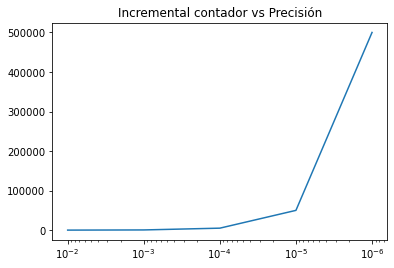

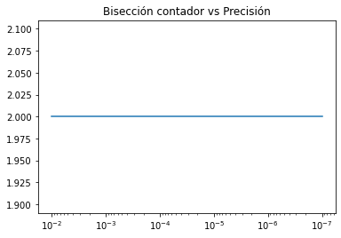

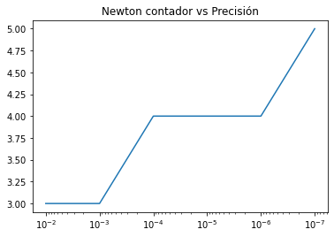

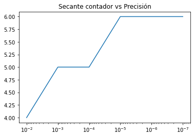

| Precisión | Incremental Raíz | Incremental Contador | Bisección Raíz | Bisección Contador | Newton Raíz | Newton Contador | Secante Raíz | Secante Contador |
| --- | --- | --- | --- | --- | --- | --- | --- | --- |
| 1.000000e-02 | 0.495 | 49.0 | 0.5 | 2.0 | 0.5 | 3.0 | 0.502627 | 4.0 |
| 1.000000e-03 | 0.4995 | 499.0 | 0.5 | 2.0 | 0.5 | 3.0 | 0.499961 | 5.0 |
| 1.000000e-04 | 0.50005 | 5000.0 | 0.5 | 2.0 | 0.5 | 4.0 | 0.499961 | 5.0 |
| 1.000000e-05 | 0.499995 | 49999.0 | 0.5 | 2.0 | 0.5 | 4.0 | 0.500000 | 6.0 |
| 1.000000e-06 | 0.5 | 500000.0 | 0.5 | 2.0 | 0.5 | 4.0 | 0.500000 | 6.0 |
| 1.000000e-07 | Algoritmo Detenido | NaN | 0.5 | 2.0 | 0.5 | 5.0 | 0.500000 | 6.0 |

```python
guerra(f,0,2,df)
```

Nuevamente todos los algoritmos son bastante buenos excepto el de incremental. El de Newton parece requerir un poquito menos pasos que el de secante y llega a la solución exacta más rápido. El de bisección llega a la solución exacta en 2 pasos, pues resulta que la raíz se encuentra justo a un cuarto de camino del intervalo.

Entonces la raíz es

### $x = 0.5 \pm 1e-7$

## 2. $f(x) = \cos(x) + (1+x^2)^{-1} $

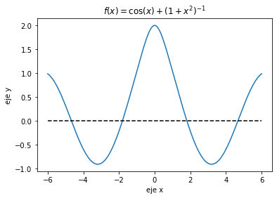

```python
# Definimos la función y su derivada y graficamos en cierto intervalo
def f(x):
    return(np.cos(x)+(1+x**2)**(-1))

def df(x):
    return(-np.sin(x)-2*x/(1+x**2)**2)

grafica(f,-6,6, r'$f(x) = \cos(x) + (1+x^2)^{-1}$')
```

La función parece ser bastante suave y tiene varias raíces. De hecho, tiene infinitas raíces, pues conforme x se hace grande, la función se parece mucho a un coseno. Sin embargo, nos centraremos sólo en las raíces entre -6 y 6. Como es una función bastante suave, cualquiera de los métodos podría funcionar.

Probamos primero en el intervalo -6 a -4 pues parece haber una raíz por ahí.

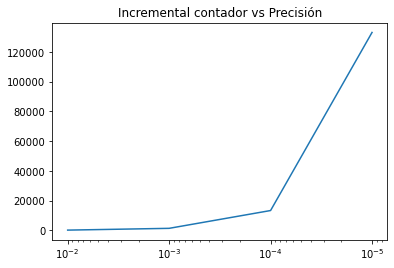

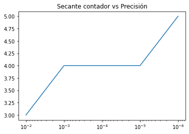

| Precisión | Incremental Raíz | Incremental Contador | Bisección Raíz | Bisección Contador | Newton Raíz | Newton Contador | Secante Raíz | Secante Contador |
| --- | --- | --- | --- | --- | --- | --- | --- | --- |
| 0.010000 | -4.665 | 133.0 | -4.664062 | 8.0 | -4.668508 | 2.0 | -4.660887 | 3.0 |
| 0.001000 | -4.6685 | 1331.0 | -4.668945 | 11.0 | -4.668506 | 3.0 | -4.668496 | 4.0 |
| 0.000100 | -4.66855 | 13314.0 | -4.668518 | 15.0 | -4.668506 | 3.0 | -4.668496 | 4.0 |
| 0.000010 | -4.668505 | 133149.0 | -4.668510 | 18.0 | -4.668506 | 3.0 | -4.668496 | 4.0 |
| 0.000001 | Algoritmo Detenido | NaN | -4.668506 | 21.0 | -4.668506 | 4.0 | -4.668506 | 5.0 |

```python
# Le bajo la precisión máxima de la default 10e-7 a 10e-6, porque sino tardaba un par de segundos
# y lo quiero casi instantáneo
guerra(f,-6,-4,df,maxi=6)
```

Vemos que el algoritmo incremental es tan malo como siempre y requiere muchos pasos. Los otros algoritmos son bastante buenos, pero el de Newton y secante llegan a respuestas igual de precisas que el de bisección mucho más rápido que este último.

Por lo que la primera raíz es

### $x = -4.668506 \pm 1e-6$

Ahora buscamos la raíz que hay entre -3 y -1

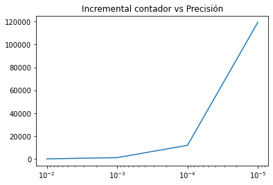

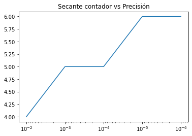

| Precisión | Incremental Raíz | Incremental Contador | Bisección Raíz | Bisección Contador | Newton Raíz | Newton Contador | Secante Raíz | Secante Contador |
| --- | --- | --- | --- | --- | --- | --- | --- | --- |
| 0.010000 | -1.805 | 119.0 | -1.804688 | 8.0 | -1.807358 | 2.0 | -1.805359 | 4.0 |
| 0.001000 | -1.8075 | 1192.0 | -1.807617 | 11.0 | -1.807375 | 3.0 | -1.807388 | 5.0 |
| 0.000100 | -1.80735 | 11926.0 | -1.807434 | 15.0 | -1.807375 | 3.0 | -1.807388 | 5.0 |
| 0.000010 | -1.807375 | 119262.0 | -1.807381 | 18.0 | -1.807375 | 4.0 | -1.807375 | 6.0 |
| 0.000001 | Algoritmo Detenido | NaN | -1.807376 | 21.0 | -1.807375 | 4.0 | -1.807375 | 6.0 |

```python
guerra(f,-3,-1,df,maxi=6)
```

Nuevamente, el de Newton y Secante son los mejores, luego el de bisección y finalmente y mucho peor, el de incremental

Entonces, la solución es

### $ x = -1.807375 \pm 1e-6$

Ahora buscamos la raíz entre 1 y 3

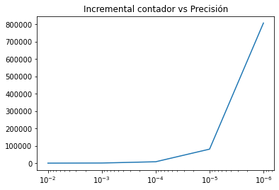

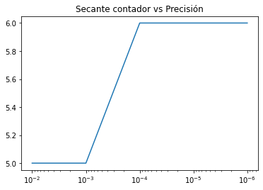

| Precisión | Incremental Raíz | Incremental Contador | Bisección Raíz | Bisección Contador | Newton Raíz | Newton Contador | Secante Raíz | Secante Contador |
| --- | --- | --- | --- | --- | --- | --- | --- | --- |
| 0.010000 | 1.805000 | 80.0 | 1.804688 | 8.0 | 1.807358 | 2.0 | 1.807740 | 5.0 |
| 0.001000 | 1.807500 | 807.0 | 1.807617 | 11.0 | 1.807375 | 3.0 | 1.807740 | 5.0 |
| 0.000100 | 1.807350 | 8073.0 | 1.807434 | 15.0 | 1.807375 | 3.0 | 1.807375 | 6.0 |
| 0.000010 | 1.807375 | 80737.0 | 1.807381 | 18.0 | 1.807375 | 4.0 | 1.807375 | 6.0 |
| 0.000001 | 1.807375 | 807375.0 | 1.807376 | 21.0 | 1.807375 | 4.0 | 1.807375 | 6.0 |

```python
guerra(f,1,3,df,maxi=6)
```

Encontramos los mismos comportamientos que antes. Ahora la solución es

### $x = 1.807375 \pm 1e-6$

Y ahora para el intervalo 4,6

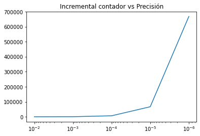

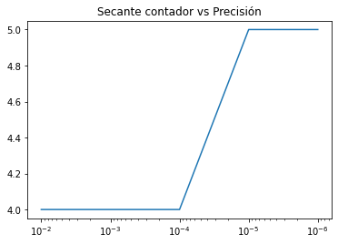

| Precisión | Incremental Raíz | Incremental Contador | Bisección Raíz | Bisección Contador | Newton Raíz | Newton Contador | Secante Raíz | Secante Contador |
| --- | --- | --- | --- | --- | --- | --- | --- | --- |
| 0.010000 | 4.665000 | 66.0 | 4.664062 | 8.0 | 4.668508 | 2.0 | 4.668459 | 4.0 |
| 0.001000 | 4.668500 | 668.0 | 4.668945 | 11.0 | 4.668506 | 3.0 | 4.668459 | 4.0 |
| 0.000100 | 4.668550 | 6685.0 | 4.668518 | 15.0 | 4.668506 | 3.0 | 4.668459 | 4.0 |
| 0.000010 | 4.668505 | 66850.0 | 4.668510 | 18.0 | 4.668506 | 3.0 | 4.668506 | 5.0 |
| 0.000001 | 4.668506 | 668505.0 | 4.668506 | 21.0 | 4.668506 | 4.0 | 4.668506 | 5.0 |

```python
guerra(f,4,6,df,maxi=6)
```

El comportamiento es el mismo que antes.

La raíz parece ser:

### $ x = 4.668506 \pm 1e-6$

# 3. $f(x) = (x-2)^2 - ln(x)$

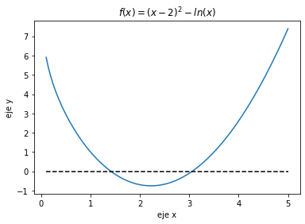

```python
# Definimos la función y su derivada
def f(x):
    return((x-2)**2-np.log(x))
def df(x):
    return(2*(-2+x)-1/x)

# Y graficamos entre 0.1 y 5 (la función diverge en 0)
grafica(f,0.1,5,r'$f(x) = (x-2)^2 - ln(x)$')
```

Dentro de este intervalo, la función parece muy suave y manejable. Por lo que cualquier método va a funcionar. Y probablemente, al igual que antes, el método con menos iteraciones sea el de Newton.

Aplicaremos los métodos para dos intervalos distintos para encontrar cada una de las dos raíces.

Ahora para el intervalo 1,2 donde parece haber una raíz

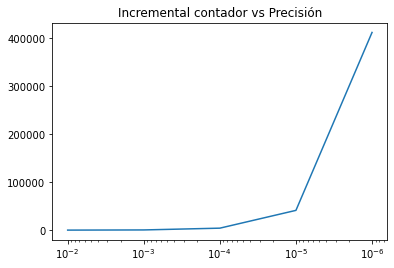

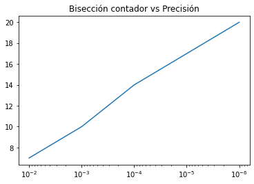

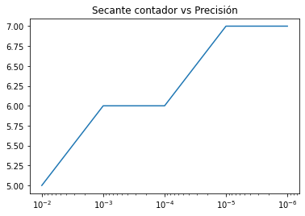

| Precisión | Incremental Raíz | Incremental Contador | Bisección Raíz | Bisección Contador | Newton Raíz | Newton Contador | Secante Raíz | Secante Contador |
| --- | --- | --- | --- | --- | --- | --- | --- | --- |
| 0.010000 | 1.415000 | 41.0 | 1.414062 | 7.0 | 1.412370 | 2.0 | 1.413635 | 5.0 |
| 0.001000 | 1.412500 | 412.0 | 1.413086 | 10.0 | 1.412391 | 3.0 | 1.412378 | 6.0 |
| 0.000100 | 1.412350 | 4123.0 | 1.412415 | 14.0 | 1.412391 | 3.0 | 1.412378 | 6.0 |
| 0.000010 | 1.412395 | 41239.0 | 1.412392 | 17.0 | 1.412391 | 4.0 | 1.412391 | 7.0 |
| 0.000001 | 1.412391 | 412391.0 | 1.412391 | 20.0 | 1.412391 | 4.0 | 1.412391 | 7.0 |

```python
guerra(f,1,2,df,maxi=6)
```

Como esperábamos, el método de Newton llegó a mejores precisiones más rápido que los demás, seguido por el de secante y el de bisección. El incremental requirió muchas iteraciones como siempre.

La primera raíz es:

## $x = 1.412391 \pm 1e-6$

Buscamos ahora la segunda raíz, que parece estar entre 2 y 4.

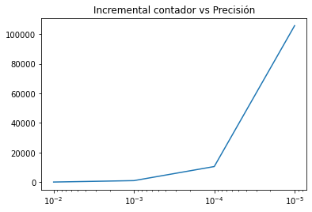

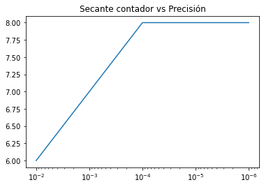

| Precisión | Incremental Raíz | Incremental Contador | Bisección Raíz | Bisección Contador | Newton Raíz | Newton Contador | Secante Raíz | Secante Contador |
| --- | --- | --- | --- | --- | --- | --- | --- | --- |
| 0.010000 | 3.055 | 105.0 | 3.054688 | 8.0 | 3.057106 | 2.0 | 3.050671 | 6.0 |
| 0.001000 | 3.0575 | 1057.0 | 3.057617 | 11.0 | 3.057104 | 3.0 | 3.057289 | 7.0 |
| 0.000100 | 3.05715 | 10571.0 | 3.057068 | 15.0 | 3.057104 | 3.0 | 3.057103 | 8.0 |
| 0.000010 | 3.057105 | 105710.0 | 3.057106 | 18.0 | 3.057104 | 3.0 | 3.057103 | 8.0 |
| 0.000001 | Algoritmo Detenido | NaN | 3.057103 | 21.0 | 3.057104 | 4.0 | 3.057103 | 8.0 |

```python
guerra(f,2,4,df,maxi=6)
```

Encontramos el mismo comportamiento que antes.

La raíz encontrada tiene un valor de:

### $x = 3.057104 \pm 1e-6$

## 4. $x^3 - 14x + 50$

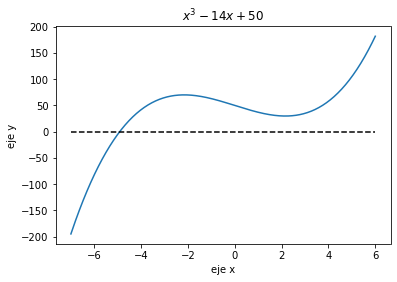

```python
# Graficamos
def f(x):
    return(x**3-14*x+50)
def df(x):
    return(3*x**2-14)

grafica(f,-7,6,r'$x^3 - 14x + 50$ ')
```

La función parece tener una sola raíz, que se encuentra cerca de -5. Como la función es muy suave, cualquiera de los métodos será válido. Así que nuevamente haremos una guerra de los métodos para encontrar el mejor, pero seguramente será el de Newton de nuevo. Tomaremos el intervalo entre -6 y -4 que se ve que contiene a la raíz

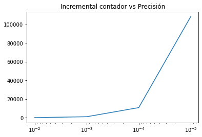

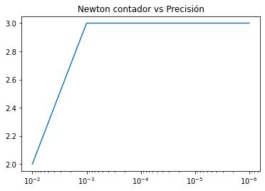

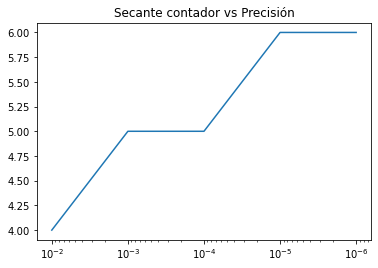

| Precisión | Incremental Raíz | Incremental Contador | Bisección Raíz | Bisección Contador | Newton Raíz | Newton Contador | Secante Raíz | Secante Contador |
| --- | --- | --- | --- | --- | --- | --- | --- | --- |
| 0.010000 | -4.915 | 108.0 | -4.914062 | 8.0 | -4.916321 | 2.0 | -4.911979 | 4.0 |
| 0.001000 | -4.9165 | 1083.0 | -4.916992 | 11.0 | -4.916321 | 3.0 | -4.916245 | 5.0 |
| 0.000100 | -4.91635 | 10836.0 | -4.916321 | 15.0 | -4.916321 | 3.0 | -4.916245 | 5.0 |
| 0.000010 | -4.916325 | 108367.0 | -4.916313 | 18.0 | -4.916321 | 3.0 | -4.916321 | 6.0 |
| 0.000001 | Algoritmo Detenido | NaN | -4.916320 | 21.0 | -4.916321 | 3.0 | -4.916321 | 6.0 |

```python
guerra(f,-6,-4,df,maxi=6)
```

Vemos que todos los métodos convergen a la misma raíz aproximadamente. Y nuevamente, el de Newton es el que converge con menor número de iteraciones con una gran precisión.

La solución es:

### $ x = -4.916321 \pm 1e-6$

# 2. Raíces

**La ecuación de Bernoulli para el flujo de un fluído en un canal abierto con una pequeña protuberancia es:**

$ \dfrac{Q^2}{2gb^2h_0^2} + h_0 = \dfrac{Q^2}{2gb^2h^2} + h +H$

**Donde:**

$Q = 1.2 m^3 /s$ = tasa de volumen de flujo  
$g = 9.81 m/s^2$ = aceleracion de la gravedad  
$b = 1.8 m$ = ancho del canal  
$ h_0 = 0.6m$ = nivel del agua  
$H = 0.075m $ - altura de protuberancia  
$ h = h$ por determinar

**Resuelve con dos métodos que prefiereas. Explica por qué escoges estos dos métodos**

Depejamos para replantear el problema como una búsqueda de una raíz h

$\dfrac{Q^2}{2gb^2h_0^2} + h_0 - \dfrac{Q^2}{2gb^2h^2} - h -H = 0$

Buscamos las raíces de la función $f(h) = \dfrac{Q^2}{2gb^2h_0^2} + h_0 - \dfrac{Q^2}{2gb^2h^2} - h -H$

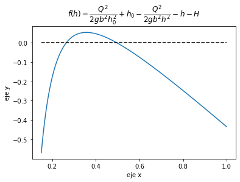

```python
import numpy as np
import matplotlib.pyplot as plt
Q = 1.2
g = 9.81
b = 1.8
h0 = 0.6
H = 0.075

# Definimos la función y su derivada
def f(h):
    return(Q**2/(2*g*b**2*h0**2) + h0  - Q**2/(2*g*b**2*h**2) - h -H )
def df(h):
    return(-1+Q**2/(b**2*g*h**3))

# Graficamos
grafica(f,0.15,1,r'$f(h) = \dfrac{Q^2}{2gb^2h_0^2} + h_0 - \dfrac{Q^2}{2gb^2h^2} - h -H$ ')
```

La función parece comportarse bastante bien en el intervalo y tiene dos raíces. Más allá de estos valores de h, empieza a predominar el término -h y ya no habrá raíces. Es decir, hay dos posible valores para h.

Como la función se ve bastante suave y pudimos calcular la derivada con facilidad, podremos usar cualquiera de los métodos sin problema. Solamente vamos a tener que usarlos en dos intervalos distintos para encontrar las dos raíces.

El método de Newton ha sido el mejor hasta ahora, así que nos fijaremos en él y después el método de secante. Sin embargo, ya que tenemos definida la función guerra, la usaremos también en este ejercicio para comparar los métodos.

Buscamos primero la raíz del lado izquierdo, entre 0.15 y 0.3

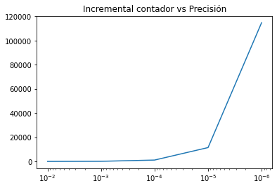

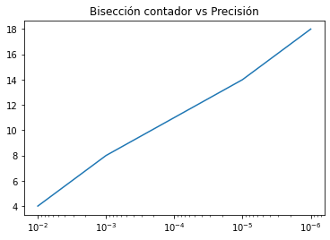

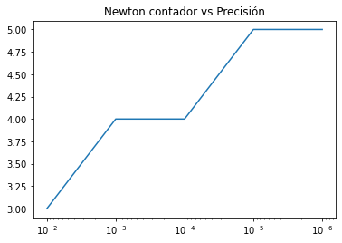

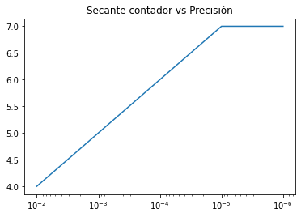

| Precisión | Incremental Raíz | Incremental Contador | Bisección Raíz | Bisección Contador | Newton Raíz | Newton Contador | Secante Raíz | Secante Contador |
| --- | --- | --- | --- | --- | --- | --- | --- | --- |
| 0.010000 | 0.265000 | 11.0 | 0.271875 | 4.0 | 0.264743 | 3.0 | 0.268124 | 4.0 |
| 0.001000 | 0.264500 | 114.0 | 0.264258 | 8.0 | 0.264755 | 4.0 | 0.265147 | 5.0 |
| 0.000100 | 0.264750 | 1147.0 | 0.264771 | 11.0 | 0.264755 | 4.0 | 0.264742 | 6.0 |
| 0.000010 | 0.264755 | 11475.0 | 0.264761 | 14.0 | 0.264755 | 5.0 | 0.264755 | 7.0 |
| 0.000001 | 0.264755 | 114755.0 | 0.264755 | 18.0 | 0.264755 | 5.0 | 0.264755 | 7.0 |

```python
guerra(f,0.15,0.3,df,maxi=6)
```

Vemos que el método de Newton converge con el menor número de iteraciones, y luego el de secante. La primera raíz es:

### $h=0.264755 \pm 1e-6$

Ahora probamos en el intervalo de 0.4 a 0.6 donde parece estar la otra raíz

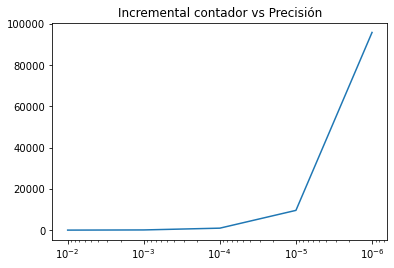

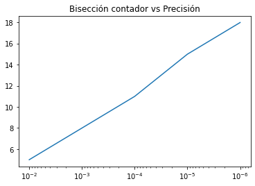

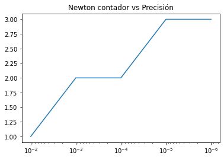

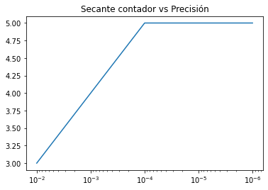

| Precisión | Incremental Raíz | Incremental Contador | Bisección Raíz | Bisección Contador | Newton Raíz | Newton Contador | Secante Raíz | Secante Contador |
| --- | --- | --- | --- | --- | --- | --- | --- | --- |
| 0.010000 | 0.495000 | 9.0 | 0.493750 | 5.0 | 0.495786 | 1.0 | 0.493094 | 3.0 |
| 0.001000 | 0.495500 | 95.0 | 0.496094 | 8.0 | 0.495755 | 2.0 | 0.495857 | 4.0 |
| 0.000100 | 0.495750 | 957.0 | 0.495801 | 11.0 | 0.495755 | 2.0 | 0.495755 | 5.0 |
| 0.000010 | 0.495755 | 9575.0 | 0.495758 | 15.0 | 0.495755 | 3.0 | 0.495755 | 5.0 |
| 0.000001 | 0.495755 | 95755.0 | 0.495756 | 18.0 | 0.495755 | 3.0 | 0.495755 | 5.0 |

```python
guerra(f,0.4,0.6,df, maxi=6)
```

Nuevamente el método de Newton es el mejor, seguido por el de secante. Y parece que la otra posible raíz es

## $ x = 0.495755 \pm 1e-6$